# creative-data-visualization

Matt Ming

5/17/2022

This data visualization will give us a plot which shows which letters are the most common first letter, second letter, third letter, etc., in the list of the 10,000 most common words in English, as well as draw lines showing frequency of moving from one letter in one position to the next.

For example:

1. see how frequently “A” is the first letter in a word
2. see how frequently “A” is followed by “A”,“B”,“C”, etc.

Initialize all necessary packages:

```r
library(dplyr)
library(ggplot2)
library(readr)
library(tidyr)
library(data.table)
```

First, load in the data set

```r
fi <- "https://raw.githubusercontent.com/difiore/ada-2022-datasets/main/google-10000-english-usa-no-swears.txt"
d <- read_csv(fi,col_names = TRUE)
words <- d$words
```

This data set contains a list of the 10,000 most commons words in English, not including swears, as measured by google.

Some data cleaning is necessary.

The 1,821st most common word in English is “NA” which is recognized by R as NA rather than as a character string, so I need to convert this entry to the character string “NA”.

```r
words[1821] <- "NA"
```

Now, I want to figure out the longest word in the list so I know how long to set my x-axis.

```r
max(nchar(words))
```

```
## [1] 18
```

Create a dataframe to store every letter of every position of every word.

Empty positions (i.e., positions after the length of the words, such as positions 5-18 in the word “boat”) are stored as NA. The max word length is 18, so all words have 18 positions containing either letters (in all caps) or NA. This data frame will be called `l` for “letters”

```r
l <- data.frame(matrix(NA,nrow = 9884,ncol = 18))
```

Now, we want to fill the data frame by iterating through all words in list, putting each letter into its respective column in dataframe (e.g., 1st letter in first column, etc.)

```r
for(i in 1:length(words)){
  s <- strsplit(words[i],"")[[1]]
  l[i,1:length(s)] <- s
}
```

Now, we need to get a data frame which will store the frequency of each letter at each position in each word. This data frame will be called `f` for “frequency”.

Note that we use a helper variable `r` to keep track of which row we’re adding to.

```r
f <- data.frame(letter = rep(NA,26*18),position = rep(NA,26*18),count = rep(NA,26*18))
r <- 1
for(i in LETTERS){
  for(j in 1:18){
    f[r,1] <- i
    f[r,2] <- j
    f[r,3] <- length(which(l[[j]] == i))
    r = r+1
  }
}
```

Converting the data to factors

```r
f$position <- factor(f$position)
f$letter <- factor(f$letter,levels = rev(LETTERS))
```

Now, transforming the data frame to keep track of all words, including all connections between letters. Essentially, we will treat all words as independent time series, with the letter position as the time variable, and will use this to plot the connections between letters.

```r
l2 <- rbind(1:18,l)
l2 <- data.frame(t(l2))
l2$X1 <- as.numeric(l2$X1)
l2$X1 <- factor(l2$X1)
l2 <- melt(as.data.table(l2),"X1")
l2$value <- factor(l2$value,levels = rev(LETTERS))
l2$variable <- factor(l2$variable,levels = rev(levels(l2$variable)))
l2$variable <- as.numeric(l2$variable)
l2 <- na.omit(l2)
```

Finally, we create a plot of the frequency of all letters, including adding in lines showing the transitions between letters.

Here, the x-axis is letter position (i.e., where in the word each letter occurs) and the y-axis is letter (ordered alphabetically). The size of the letters indicates how common that letter is for that specific position in a word. The lines represent connections between letters, with more opaque lines representing more common connections. More red lines correspond to connections in very common words, whereas blue lines are for connections in less common words.

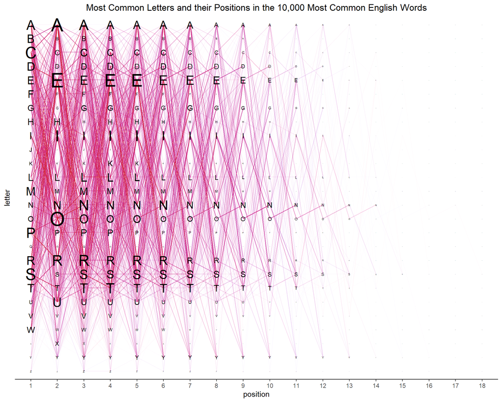

```r
p <- ggplot(data = f,aes(x = position,y = letter)) +
  geom_line(data = l2,aes(x = X1,y = value,group = variable,color = variable),
            alpha = 0.01) +
  geom_text(aes(size = count,label = rep(LETTERS,each = 18))) +
  scale_size_continuous(range = c(0,10)) +
  scale_color_gradient(low = "blue",high = "red") +
  ggtitle("Most Common Letters and their Positions in the 10,000 Most Common English Words") +
  theme(panel.background = element_blank(),
        legend.position = "none",
        axis.text.y.left = element_blank(),
        axis.ticks.y = element_blank(),
        axis.line.x.bottom = element_line("black"),
        plot.title = element_text(hjust = 0.5))
print(p)
```

How to interpret:

This figure uses larger letters to represent the most common letters in each position. For example, we can see that A, E, and O are very common second letters in words, while C and S are two of the most common first letters.

This figure also uses lines drawn between each letter to represent connections between letters within words. Here, we can see that Y is most often preceded by L, T, or R because of the darker, more opaque and visible lines coming out of L, T, and R and ending in Y. We can also see that many common words start with C and then the second letter is O, as evidenced by the large density of lines at between C and O in the first and second positions, respectively. Also note that the color of the lines indicate word commonness, with red lines being associated with the most common words, and blue lines with the least common.